# SLW7_IEEEFraudDetection

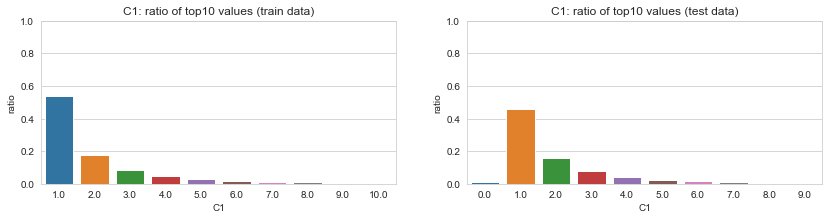

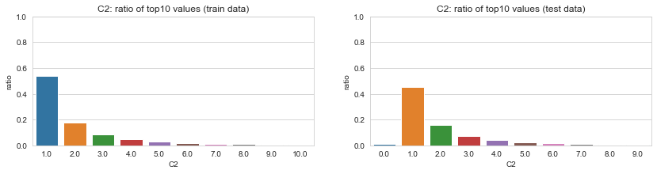

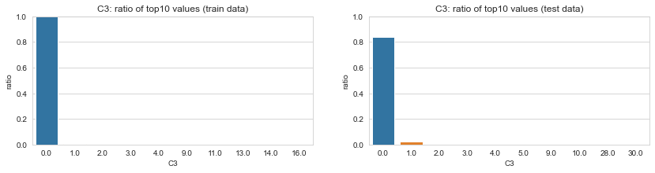

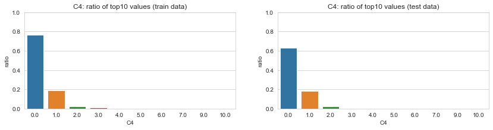

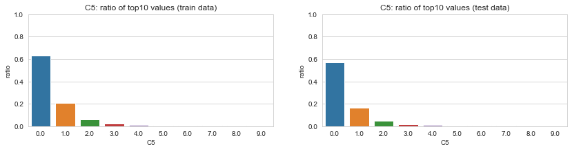

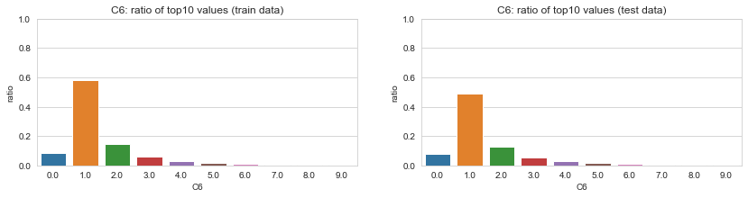

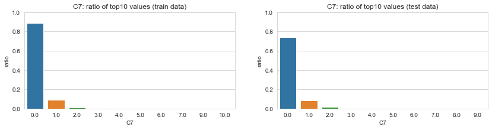

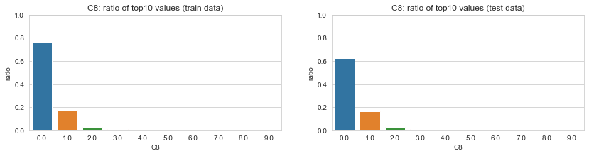

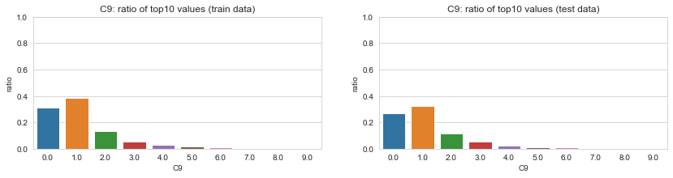

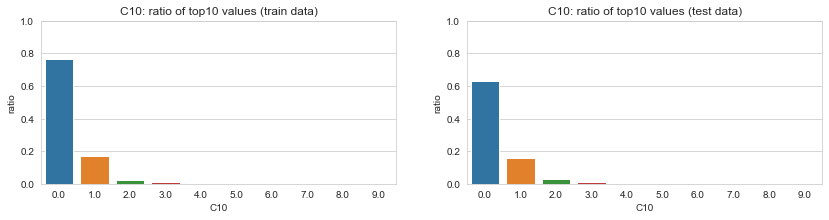

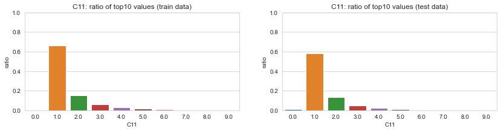

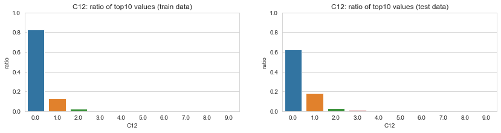

[2 more figures not shown]

```python
for label in numeric_C:
    ratio_x(train_tr, test_tr, label)
```

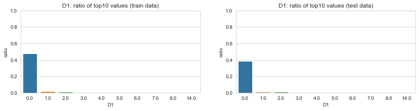

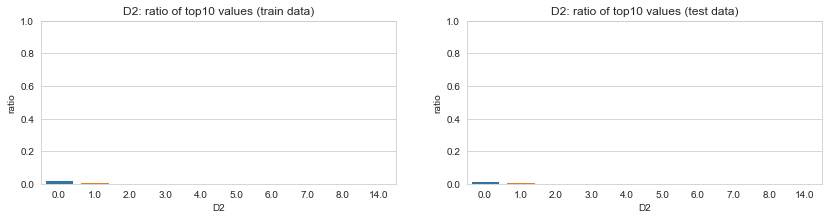

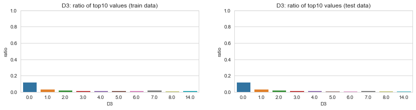

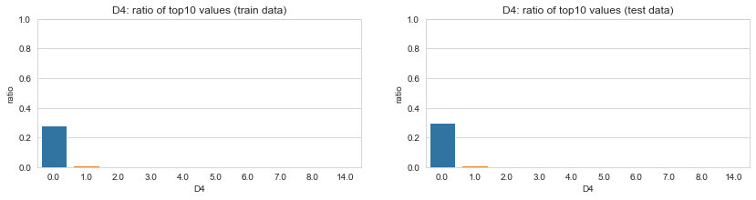

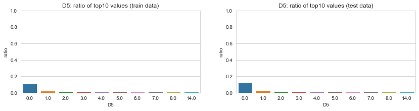

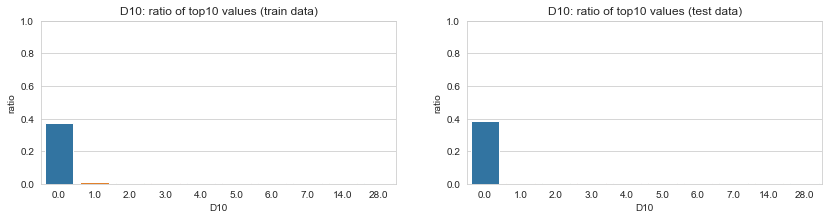

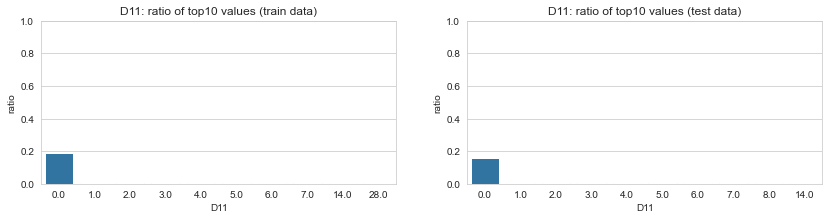

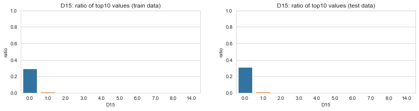

```python
for label in numeric_D:
    ratio_x(train_tr, test_tr, label)
```

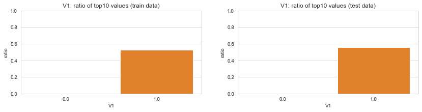

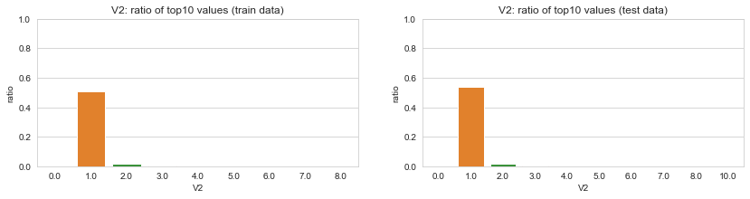

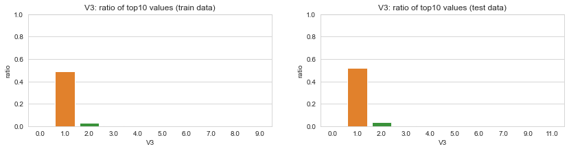

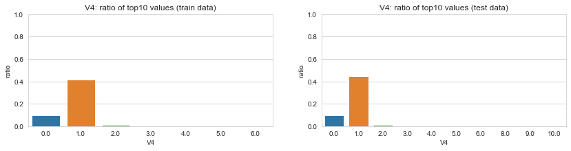

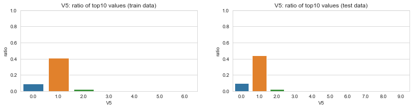

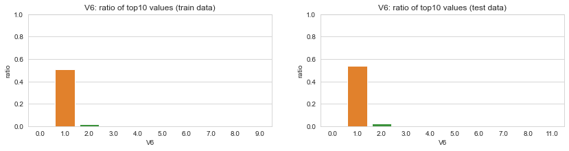

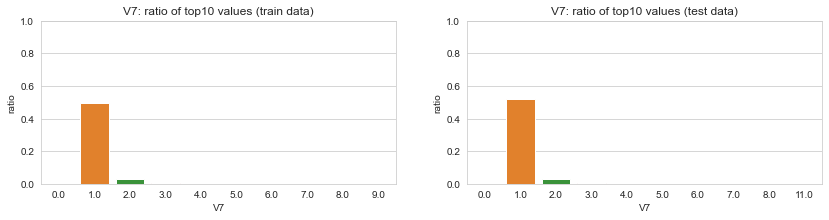

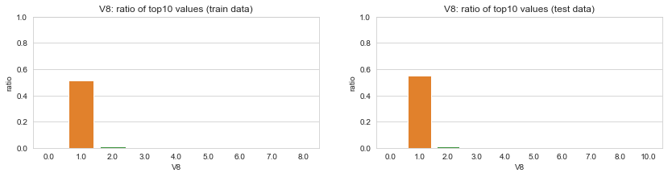

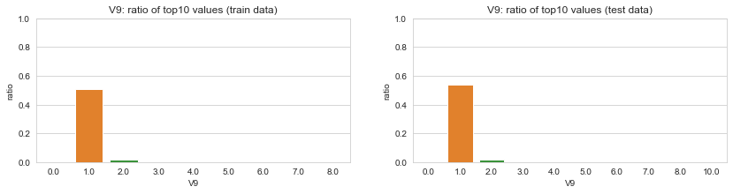

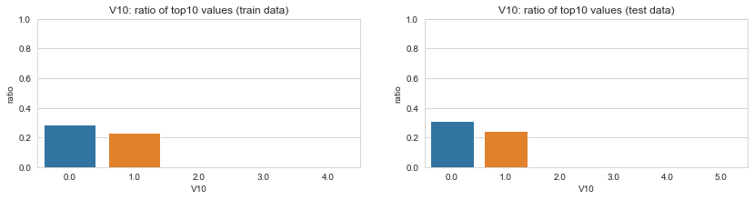

```python
for label in numeric_V[0:10]:
    ratio_x(train_tr, test_tr, label)
```

It may be useful to divide email domain by ".", before "." represents company and domain after "." shows countries.

```python
filter1 = train_tr["P_emaildomain"].isna()
train_tr.loc[filter1,"P_emaildomain"] = "none.none"
train_tr["P_emaildomain_Head"] = train_tr["P_emaildomain"].apply(lambda x: x.split(".")[0])
train_tr["P_emaildomain_Tail"] = train_tr["P_emaildomain"].apply(lambda x: x.split(".")[-1])
```

```python
filter1 = test_tr["P_emaildomain"].isna()
test_tr.loc[filter1,"P_emaildomain"] = "none.none"
test_tr["P_emaildomain_Head"] = test_tr["P_emaildomain"].apply(lambda x: x.split(".")[0])
test_tr["P_emaildomain_Tail"] = test_tr["P_emaildomain"].apply(lambda x: x.split(".")[-1])
```

```python
train_tr["P_emaildomain_Head"].unique(), test_tr["P_emaildomain_Tail"].unique()
```

```
(array(['none', 'gmail', 'outlook', 'yahoo', 'mail', 'anonymous',
        'hotmail', 'verizon', 'aol', 'me', 'comcast', 'optonline', 'cox',
        'charter', 'rocketmail', 'prodigy', 'embarqmail', 'icloud', 'live',
        'att', 'juno', 'ymail', 'sbcglobal', 'bellsouth', 'msn', 'q',
        'centurylink', 'servicios-ta', 'earthlink', 'cfl', 'roadrunner',
        'netzero', 'gmx', 'suddenlink', 'frontiernet', 'windstream',
        'frontier', 'mac', 'aim', 'web', 'twc', 'cableone', 'sc', 'ptd',
        'protonmail'], dtype=object),
 array(['com', 'none', 'net', 'de', 'mx', 'es', 'fr', 'uk', 'gmail', 'jp',
        'edu'], dtype=object))
```

## 3.3 Imputation

How to impute NaN depends on type of data, ratio of NaN, and data distribution. If data is numeric, **mean** value is selected. If data is categorical, and NaN ratio is small and the one value occupies high ratio, **mode** (most frequent value) is selected. Otherwize, new category (Z or -255) fills NaN of categorical columns.

**Mean Value**

- dist1
- Numeric Group C, D, V

**Most Frequent Value**

- card3, card4, card5
- add2

**"Z"**

**-255**

- card2
- addr1

```python
def impute_num(df, label, num):
    filter1 = df[label].isna()
    df.loc[filter1,label] = num
```

```python
# Mode
labels = ['card3', 'card4', 'card5',
          'addr2',]

for label in labels:
    try:
        mode_v = train_tr[label].mode()[0]
        impute_num(train_tr, label, mode_v)
        impute_num(test_tr, label, mode_v)
    except KeyError:
        pass


#Z
labels = ['card4',  'card6',
          'M4', 'M5', 'M6', 'M8',
                    'M1', 'M2', 'M3', 'M7',  'M9']

for label in labels:
    try:
        impute_num(train_tr, label, "Z")
        impute_num(test_tr, label, "Z")
    except KeyError:
        pass

#-255
labels = [ 'card2',
          'addr1']

for label in labels:
    try:
        impute_num(train_tr, label, -255)
        impute_num(test_tr, label, -255)
    except KeyError:
        pass

# mean
labels =  ["dist1"]

for label in labels:
    try:
        val = int(train_tr[label].mean())
        impute_num(train_tr, label, val)
        impute_num(test_tr, label, val)
    except KeyError:
        pass
```

```python
# fill NaN with mean
for label in numeric_C + numeric_D + numeric_V:
    try:
    #val = train_tr[label].mode()[0]
        val = int(train_tr[label].mean())
        impute_num(train_tr, label, val)
        impute_num(test_tr, label, val)

    except KeyError:
        pass
```

```python
cnames = list(train_tr.columns)
```

## 3.4 Removing Outliers

Negative value in numeric C, D and V should be mistake or bug. It exists only in few rows of D4, D11, and D15. Those value should be removed (replaced by mode).

```python
## Outliers
labels = ["D4", "D11", "D15"]
for label in labels:
    filter1 = train_tr[label] < 0
    train_tr.loc[filter1,label] = train_tr[label].mode()[0]
```

# 4. EDA and Feature Engineering

## 4.1 Time Series Feature

In the data, there is a column `TransactionDT` which has integer values. The name means **transaction date and time** that can be converted into hour, day, month, and year. Then, interesting trends are visible. Fraud is highest probability at hour (`HourD`) 7. `HourCount` (**#transaction/hour**) has 24 hours cycle. `DayCount` (**#transaction/day**) has 7 days cycle.

```python
train_tr["TransactionDT"].head()
```

```
0    86400
1    86401
2    86469
3    86499
4    86506
Name: TransactionDT, dtype: int64
```

```python
# Function to generate new features

def TS_Features(df):

    df['Day']  = df['TransactionDT']//(3600*24)
    df['Hour']  = df['TransactionDT'] // 3600
    df['Month']  = df['TransactionDT'] // (3600*24*30)
    df['Year']  = df['TransactionDT'] // (3600*24*365)
    #hour of the day
    df['HourD']  = (df['TransactionDT'] // 3600 ) % 24
    #day of the year
    df['DayY']  = df['TransactionDT']//(3600*24) % 365
    df['WeekM']  = df['TransactionDT']//(3600*24*7) % 4


    #number of transaction by day and hour
    DayCount = df[["Day",ID]].groupby("Day").count().rename({ID:"DayCount"}, axis = 1).reset_index()
    HourCount= df[["Hour",ID]].groupby("Hour").count().rename({ID:"HourCount"}, axis = 1).reset_index()

    #merge feature columns
    df2 = df[["Day", ID]].merge(DayCount, on = "Day", how ="left").copy()
    df["DayCount"] = df2["DayCount"]
    df2 = df[["Hour", ID]].merge(HourCount, on = "Hour", how ="left").copy()
    df["HourCount"] = df2["HourCount"]
```

```python
TS_Features(train_tr)
TS_Features(test_tr)
```

```
(0.0, 0.12)
```

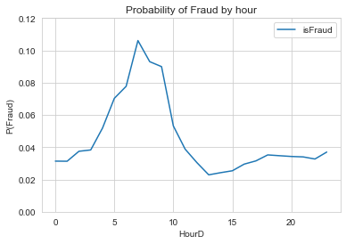

```python
fig, ax = plt.subplots()
train_tr[["HourD", Y]].groupby("HourD").mean().plot(ax = ax)
ax.set_title("Probability of Fraud by hour")
ax.set_ylabel("P(Fraud)")
ax.set_ylim(0, 0.12)
```

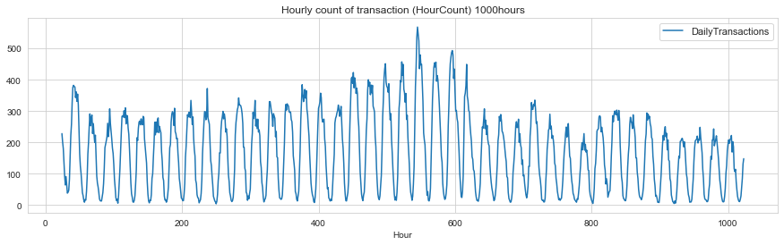

```python
select =  [ "Hour"]
fig, ax = plt.subplots(figsize = (15, 4))
train_tr[[ID] + select].groupby(select).count().rename({ID:"DailyTransactions"}, axis = 1).iloc[0:1000].plot(ax = ax)
ax.legend(fontsize = 11)
ax.set_title("Hourly count of transaction (HourCount) 1000hours")
```

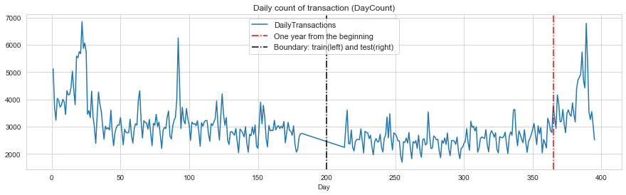

```python
select =  [ "Day"]
fig, ax = plt.subplots(figsize = (15, 4))
pd.concat([train_tr[[ID] + select].groupby(select).count(), test_tr[[ID] + select].groupby(select).count()]).rename({ID:"DailyTransactions"}, axis = 1).plot(ax = ax)
ax.axvline(x = 365, ls = "-.", color = "red", label = "One year from the beginning")
ax.axvline(x = 200, ls = "-.", color = "black", label = "Boundary: train(left) and test(right) ")
ax.legend(fontsize = 11)
ax.set_title("Daily count of transaction (DayCount)")
```

## 4.2 Numeric C and D

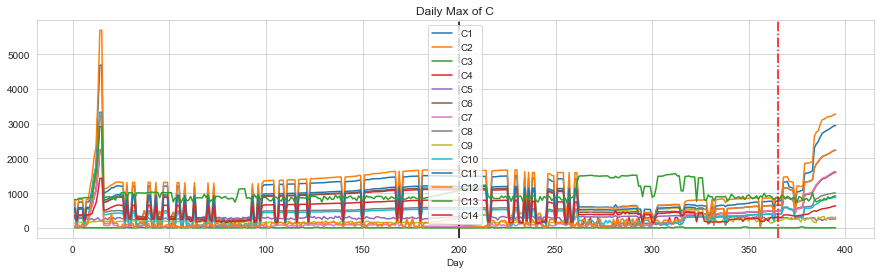

```python
fig, ax = plt.subplots()
pd.concat([train_tr[["Day"] + numeric_C].groupby("Day").max().iloc[0:,:],  test_tr[["Day"] + numeric_C].groupby("Day").max().iloc[0:,:]]).plot(figsize = (15, 4), ax = ax)
ax.set_title("Daily Max of C")
ax.axvline(x = 365, ls = "-.", color = "red", label = "One year from the beginning")
ax.axvline(x = 200, ls = "-.", color = "black", label = "Boundary: train(left) and test(right) ")
```

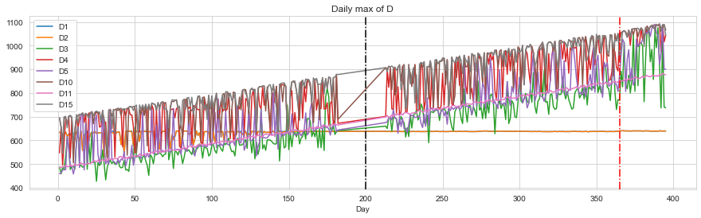

```python
fig, ax = plt.subplots()
pd.concat([train_tr[["Day"] + numeric_D].groupby("Day").max().iloc[0:,:],  test_tr[["Day"] + numeric_D].groupby("Day").max().iloc[0:,:]]).plot(figsize = (15, 4), ax = ax)
ax.set_title("Daily max of D")
ax.axvline(x = 365, ls = "-.", color = "red", label = "One year from the beginning")
ax.axvline(x = 200, ls = "-.", color = "black", label = "Boundary: train(left) and test(right) ")
```

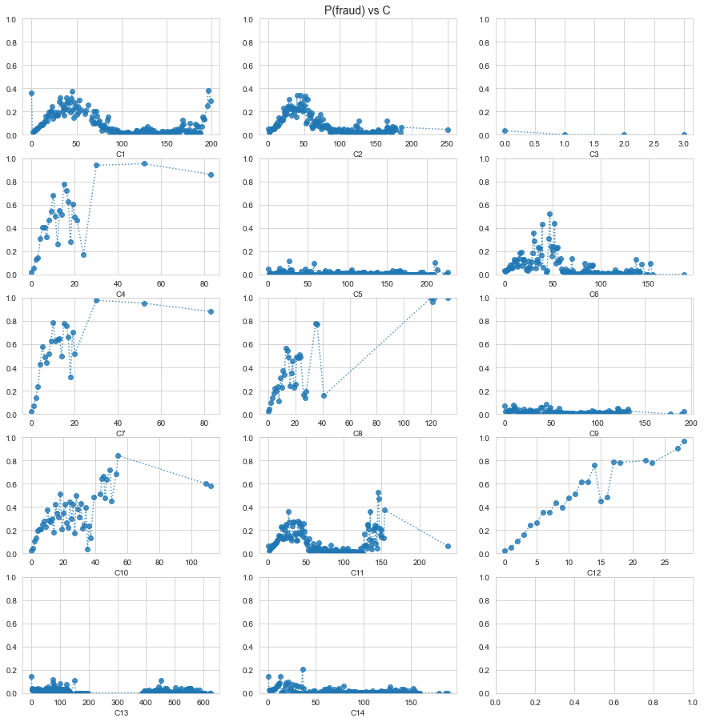

```python
N = len(numeric_C)
ncol = 3
nrow = math.ceil(N/ncol)
fig, ax = plt.subplots(nrow, ncol, figsize = (15, nrow*3.1))

for k in range(N):
    i = int(k//ncol)
    j = k % ncol
    select = numeric_C[k]
    train_tr[[select, Y]].groupby(select).agg(["mean", "count"])["isFraud"].query("count > 40")["mean"].plot(marker = "o", ls = "dotted", ax = ax[i,j], alpha = 0.8)
    ax[i,j].set_ylim(0, 1)

ax[0,1].set_title("P(fraud) vs C", fontsize = 14)
```

[figure not shown]

```python
N = len(numeric_D)
ncol = 3
nrow = math.ceil(N/ncol)
fig, ax = plt.subplots(nrow, ncol, figsize = (15, nrow*3.1))

for k in range(N):
    i = int(k//ncol)
    j = k % ncol
    select = numeric_C[k]
    train_tr[[select, Y]].groupby(select).agg(["mean", "count"])["isFraud"].query("count > 40")["mean"].plot(marker = "o", ls = "dotted", ax = ax[i,j], alpha = 0.8)
    ax[i,j].set_ylim(0, 1)

ax[0,1].set_title("P(fraud) vs D", fontsize = 14)
```

## 4.3 Numeric V

There are about 300 features in group V. Those are highly correlated. Only 16 of them are rankedin top 50 important features by Random Forest (Chapter 5)

```python
important_V = ['V29', 'V30', 'V49', 'V70', 'V90', 'V91', 'V69', 'V282', 'V283', 'V280',
               'V294', 'V307', 'V308',  'V317', 'V318', 'V310']

print("Number of important feature:", len(important_V))
```

```
Number of important feature: 16
```

```python
np.random.seed(1)
n_train = train_tr.shape[0]
train_sample = np.random.choice(n_train, 30000)
```

```python
V_cormat = train_tr[numeric_V].iloc[train_sample,:].corr()
```

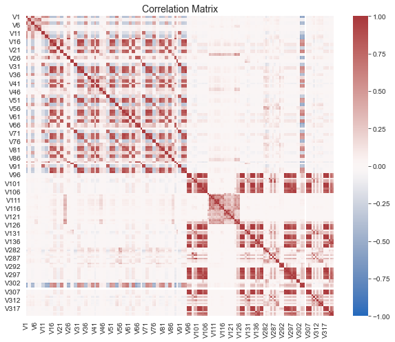

```python
fig, ax = plt.subplots(figsize = (10,8))
sns.heatmap(V_cormat, ax = ax,vmin=-1, vmax=1, cmap  = "vlag")
ax.set_title("Correlation Matrix", fontsize = 14)
```

```python
V_cormat2 = train_tr[important_V].iloc[train_sample,:].corr()
```

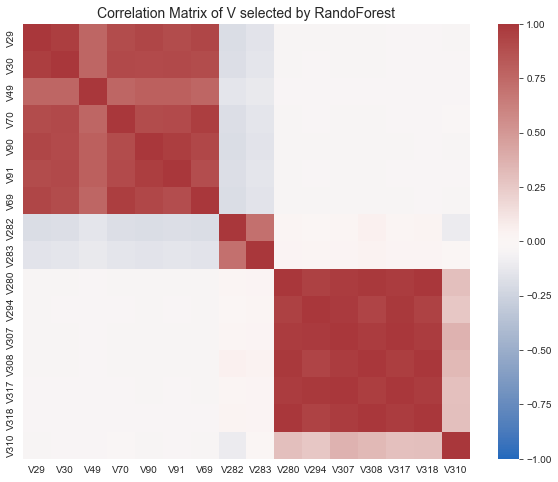

```python
fig, ax = plt.subplots(figsize = (10,8))
sns.heatmap(V_cormat2, ax = ax,vmin=-1, vmax=1, cmap  = "vlag")
ax.set_title("Correlation Matrix of V selected by RandoForest", fontsize = 14)
```

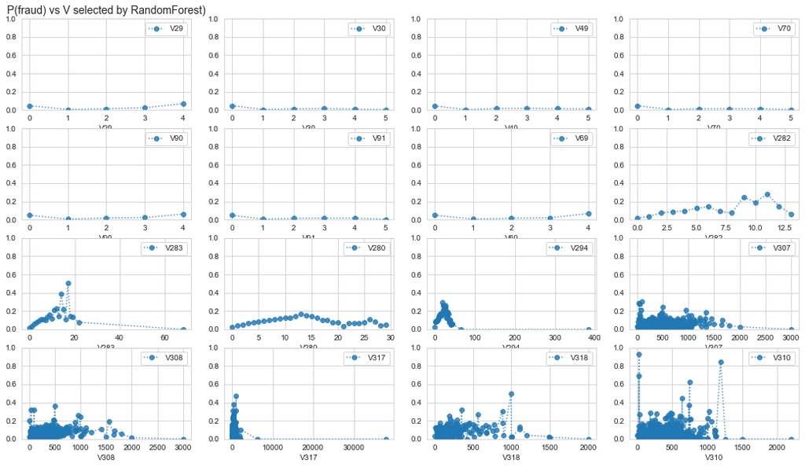

```python
N = len(important_V)
ncol = 4
nrow = math.ceil(N/ncol)
fig, ax = plt.subplots(nrow, ncol, figsize = (18, nrow*2.5))

for k in range(N):
    i = int(k//ncol)
    j = k % ncol
    select = important_V[k]
    train_tr[[select, Y]].groupby(select).agg(["mean", "count"])["isFraud"].query("count > 30")["mean"].plot(marker = "o", ls = "dotted", ax = ax[i,j], alpha = 0.8, label = select)
    ax[i,j].set_ylim(0, 1)
    ax[i,j].legend()

ax[0,0].set_title("P(fraud) vs V selected by RandomForest)", fontsize = 14)
```

## 4.4 Encoding Categorical Variables

To make ML efficient, categorical variables are encoded into probability of fraud.

```python
def value_rank_df(select, min_count = 200):

    Y = "isFraud"

    df = train_tr[[select, Y]].groupby(select).mean()
    filter1 = (train_tr[[select, Y]].groupby(select).count() > min_count)[Y]
    df2 = df.loc[filter1,:]

    keys = list(df2.index)
    vals = df2[Y].to_numpy()

    dic1 = {}
    for i in range(len(vals)):
        dic1[keys[i]] = vals[i]

    return dic1#, df2.sort_values(Y, ascending = False)
```

```python
def find_P(dic1, val):

    try:
        p = dic1[val]
        return p
    except KeyError:
        return 0.03499 #average probability
```

```python
cnames = list(train_tr.columns)
```

```python
#categorical_X = cnames[4:15] + cat_M + ["P_emaildomain_Head", "P_emaildomain_Tail"]
```

```python
#convert_X = categorical_X #+ ["HourD", "DayW"]
```

```python
convert_X = ['ProductCD', 'card1', 'card2', 'card3', 'card4', 'card5', 'card6', 'addr1', 'addr2', 'dist1',
  'P_emaildomain', 'M1', 'M2', 'M3', 'M4', 'M5', 'M6', 'M7', 'M8', 'M9',
 'P_emaildomain_Head', 'P_emaildomain_Tail']
```

```python
p_dics = {}

for label in convert_X :
    min_count = 200
    if label == "card1":
        min_count = 40
    dic1 = value_rank_df(label, min_count)
    p_dics[label] = dic1
```

```python
for label in convert_X :
    name =  "Pr_" + label
    train_tr[name] = train_tr[label].apply(lambda x: find_P(p_dics[label], x))
    test_tr[name] = test_tr[label].apply(lambda x: find_P(p_dics[label], x))
```

```python
train_tr[["ProductCD", "Pr_ProductCD"]].tail(10)
```

|  | ProductCD | Pr_ProductCD |
| --- | --- | --- |
| 590530 | W | 0.020399 |
| 590531 | R | 0.037826 |
| 590532 | W | 0.020399 |
| 590533 | W | 0.020399 |
| 590534 | C | 0.116873 |
| 590535 | W | 0.020399 |
| 590536 | W | 0.020399 |
| 590537 | W | 0.020399 |
| 590538 | W | 0.020399 |
| 590539 | W | 0.020399 |

# 5. ML

## 5.1 Splitting Data

For time series data, train and validation should not be shuffled. Thus, in the `split_train_val` function, train should be the first 70% and validation is latter 30%. Since the label Y (`isFraud`) is highly imbalanced (96.5% is negative), the function includes sampling of negative cases.

```python
def split_train_val(X, y, train_pct):

    n = X.shape[0]
    n_train = int(n*train_pct)

    #validation is latter
    X_val = X.iloc[n_train:,:]
    y_val = y[n_train:]

    # positive index
    filter1 = y[0:n_train] == 1
    n_pos = np.sum(filter1)
    pos_sample = np.where(filter1)[0]

    # negative index
    neg_indx = np.where(y[0:n_train] == 0)[0]
    np.random.seed(1)

    # sample negative same quantity as positive
    neg_sample = np.random.choice(neg_indx, n_pos)

    sample_index = np.concatenate((pos_sample, neg_sample))

    X_train = X.iloc[sample_index,:]
    y_train =  y[sample_index]

    return X_train, X_val, y_train, y_val
```

```python
#drop unnecessary columns
drop_list = ["Day", "Hour", "Month", "Year"] + convert_X
cnames = list(train_tr.drop(drop_list, axis = 1).columns)
select_X = cnames[3:]

print(len(select_X), " features are selected")
```

```
231  features are selected
```

```python
X_train, X_val, y_train, y_val = split_train_val(train_tr[select_X], Y_array, train_pct = 0.7)
```

```python
print("train data size")
print(X_train.shape)

print("validation data size")
print(X_val.shape)
```

```
train data size
(29076, 231)
validation data size
(177162, 231)
```

### Checking imbalance of Y

```python
print("Positive ratio in train data = ", np.mean(y_train))
```

```
Positive ratio in train data =  0.5
```

```python
print("Positive ratio in validation data = ", np.round(np.mean(y_val), 3))
```

```
Positive ratio in validation data =  0.035
```

## 5.1 Random Forest Classifier

To prevent overfitting of RandomForestClassifier, important features selected first. Then, max depth and ccp-alpha are tuned.

### 5.1.1 Feature Selection

```python
def train_and_validate(clf, X_train, y_train, X_val, y_val):

    clf.fit(X_train, y_train)
    yhat_train = clf.predict_proba(X_train)[:,1]
    yhat_val = clf.predict_proba(X_val)[:,1]
    fpr, tpr, thresholds = metrics.roc_curve(y_train, yhat_train, pos_label=1)
    train_auc = metrics.auc(fpr, tpr)
    fpr, tpr, thresholds = metrics.roc_curve(y_val, yhat_val, pos_label=1)
    val_auc = metrics.auc(fpr, tpr)

    return train_auc, val_auc
```

```python
clf = RandomForestClassifier(max_depth=20, random_state=0, n_estimators = 300)
train_auc, val_auc = train_and_validate(clf, X_train, y_train, X_val, y_val)
print("train auc = ", np.round(train_auc, 4),", val auc = ", np.round(val_auc, 4))
```

```
train auc =  0.996 , val auc =  0.9109
```

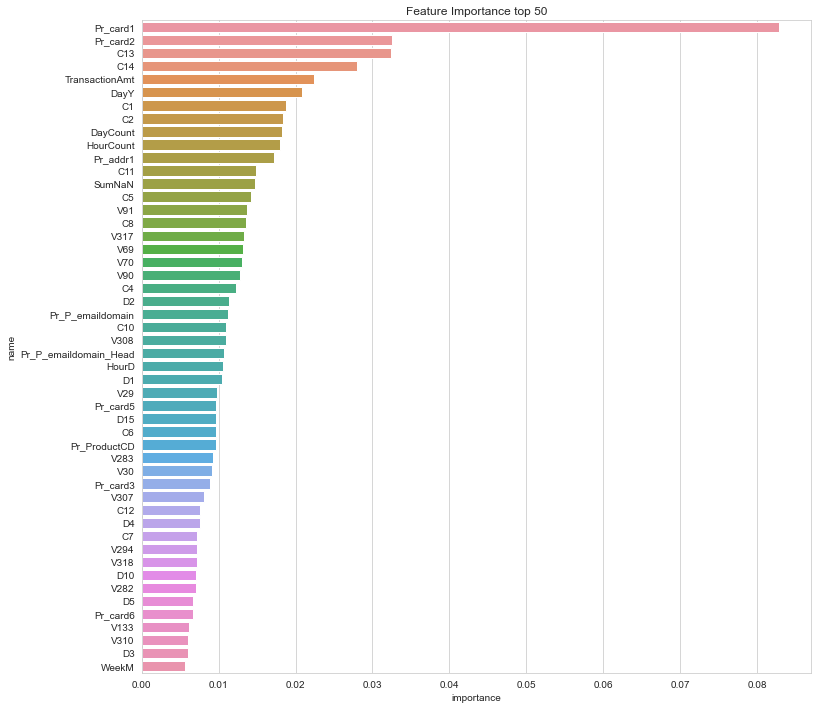

```python
imp_df = pd.DataFrame({"name" : list(train_tr[select_X].columns), "importance": clf.feature_importances_})
fig, ax = plt.subplots(figsize = (12, 12))
sns.barplot(data = imp_df.sort_values("importance", ascending = False).reset_index().iloc[0:50,:], y = "name", x = "importance", ax = ax)
ax.set_title("Feature Importance top 50")
features = list(imp_df.sort_values("importance", ascending = False).reset_index()["name"].to_numpy())
```

```python
filter1 = list(map(lambda x: x.startswith("V"), features[0:50]))
print("Top features in V:", np.array(features[0:50])[filter1])
```

```
Top features in V: ['V91' 'V317' 'V69' 'V70' 'V90' 'V308' 'V29' 'V283' 'V30' 'V307' 'V294'
 'V318' 'V282' 'V133' 'V310']
```

```python
train_score = []
val_score = []
n_features = [50, 100, 150, 200]

for n_select in n_features:

    select_X2 = features[0:n_select]
    clf = RandomForestClassifier(max_depth=20, random_state=0, n_estimators = 300)
    train_auc, val_auc = train_and_validate(clf, X_train[select_X2], y_train, X_val[select_X2], y_val)
    train_score.append(train_auc)
    val_score.append(val_auc)
    print("n_feature = ", n_select , "train auc = ", np.round(train_auc, 4),", val auc = ", np.round(val_auc, 4))
```

```
n_feature =  50 train auc =  0.999 , val auc =  0.9123
n_feature =  100 train auc =  0.998 , val auc =  0.9126
n_feature =  150 train auc =  0.9973 , val auc =  0.9132
n_feature =  200 train auc =  0.9964 , val auc =  0.9117
```

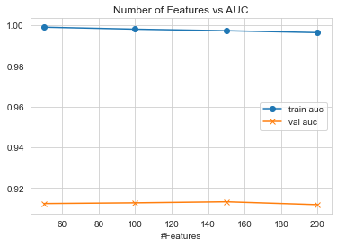

```python
fig, ax = plt.subplots()

ax.plot(n_features, train_score, label = "train auc", marker = "o")
ax.plot(n_features, val_score, label = "val auc", marker = "x")
ax.legend()
ax.set_xlabel("#Features")
ax.set_title("Number of Features vs AUC")
plt.show()
```

```python
n_select = 150
```

```python
select_X2 = features[0:n_select]
```

```python
print(len(select_X2), " features are selected")
```

```
150  features are selected
```

### 5.1.2 max depth tuning

```python
m_depths =  np.arange(5, 35, 5)
m_depths
```

```
array([ 5, 10, 15, 20, 25, 30])
```

```python
train_score = []
val_score = []
for depth in m_depths:
    clf = RandomForestClassifier(max_depth=depth, random_state=0, n_estimators = 300)
    train_auc, val_auc = train_and_validate(clf, X_train[select_X2], y_train, X_val[select_X2], y_val)
    train_score.append(train_auc)
    val_score.append(val_auc)
    print("max_depth", depth, ", train auc = ", np.round(train_auc, 4),", val auc = ", np.round(val_auc, 4))
```

```
max_depth 5 , train auc =  0.8784 , val auc =  0.8665
max_depth 10 , train auc =  0.9376 , val auc =  0.896
max_depth 15 , train auc =  0.9813 , val auc =  0.9085
max_depth 20 , train auc =  0.9973 , val auc =  0.9132
max_depth 25 , train auc =  0.9999 , val auc =  0.9142
max_depth 30 , train auc =  1.0 , val auc =  0.9139
```

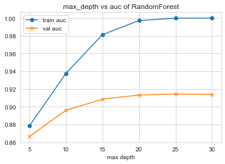

```python
fig, ax = plt.subplots()

ax.plot(m_depths, train_score, label = "train auc", marker = "o")
ax.plot(m_depths, val_score, label = "val auc", marker = "x")
ax.legend()
ax.set_xlabel("max depth")
ax.set_title("max_depth vs auc of RandomForest")
plt.show()
```

```python
print("the best max depth is", 25)
```

```
the best max depth is 25
```

### 5.1.3 ccp alpha tuning

Setting ccp alpha does not improve validation AUC. It should be 0.

```python
ccp_alphas = 1/2**(np.arange(11, 16))[::-1]
ccp_alphas
```

```
array([3.05175781e-05, 6.10351562e-05, 1.22070312e-04, 2.44140625e-04,
       4.88281250e-04])
```

```python
train_score = []
val_score = []
for ccp_a in ccp_alphas:
    clf = RandomForestClassifier(max_depth=25, random_state=0, n_estimators = 300, ccp_alpha = ccp_a)
    train_auc, val_auc = train_and_validate(clf, X_train, y_train, X_val, y_val)
    train_score.append(train_auc)
    val_score.append(val_auc)

    print("ccp_alpha", ccp_a, ", train auc = ", np.round(train_auc, 4),", val auc = ", np.round(val_auc, 4))
```

```
ccp_alpha 3.0517578125e-05 , train auc =  0.9987 , val auc =  0.9119
ccp_alpha 6.103515625e-05 , train auc =  0.9907 , val auc =  0.9104
ccp_alpha 0.0001220703125 , train auc =  0.9644 , val auc =  0.9056
ccp_alpha 0.000244140625 , train auc =  0.9291 , val auc =  0.8956
ccp_alpha 0.00048828125 , train auc =  0.9057 , val auc =  0.8845
```

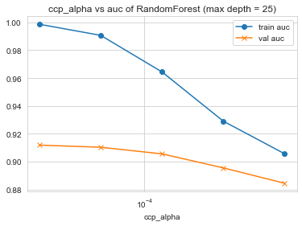

```python
fig, ax = plt.subplots()

ax.plot(ccp_alphas, train_score, label = "train auc", marker = "o")
ax.plot(ccp_alphas, val_score, label = "val auc", marker = "x")
ax.legend()
ax.set_xscale('log')
ax.set_xlabel("ccp_alpha")
ax.set_title("ccp_alpha vs auc of RandomForest (max depth = 25)")
plt.show()
```

### 5.1.4 Submission

This model achieved **AUC 0.900 in kaggle private score**. (late submission)

```python
X_train, X_val, y_train, y_val = split_train_val(train_tr[select_X2], Y_array, train_pct = 1)
X_train.shape, X_val.shape
```

```
((41326, 150), (0, 150))
```

```python
clf = RandomForestClassifier(max_depth=25, random_state=0, n_estimators = 500)
clf.fit(X_train, y_train)
```

```
RandomForestClassifier(max_depth=25, n_estimators=500, random_state=0)
```

```python
yhat_train = clf.predict_proba(X_train)[:,1]
fpr, tpr, thresholds = metrics.roc_curve(y_train, yhat_train, pos_label=1)
train_auc = metrics.auc(fpr, tpr)
train_auc
```

```
0.9995842978752867
```

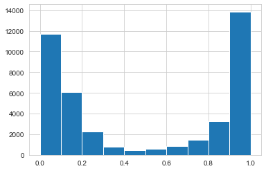

```python
#train data result
plt.hist(yhat_train)
plt.show()
```

```python
yhat_test = clf.predict_proba(test_tr[select_X2])[:,1]
```

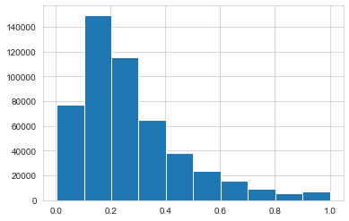

```python
#test data result
plt.hist(yhat_test)
plt.show()
```

```python
sample_df = pd.read_csv("data/sample_submission.csv")
sample_df["isFraud"] = yhat_test
sample_df.to_csv("output/RF_depth25_Col150_2.csv", index = False)
```

```python
sample_df.head()
```

|  | TransactionID | isFraud |
| --- | --- | --- |
| 0 | 3663549 | 0.099656 |
| 1 | 3663550 | 0.183950 |
| 2 | 3663551 | 0.191800 |
| 3 | 3663552 | 0.114844 |
| 4 | 3663553 | 0.138603 |

## 5.2 XG Boost

### 5.2.1 Train XGBoost Classifier

```python
import xgboost as xgb
```

```python
X_train, X_val, y_train, y_val = split_train_val(train_tr[select_X], Y_array, train_pct = 0.7)
```

```python
model = xgb.XGBClassifier(n_estimators = 100, max_depth = 12, eta = 0.15, objective = 'binary:logistic', eval_metric = 'auc', nthread = 2, early_stopping_rounds  = 10)
```

```python
model.fit(X_train, y_train, eval_set = [(X_train, y_train), (X_val, y_val)])
```

```
XGBClassifier(base_score=None, booster=None, callbacks=None,
              colsample_bylevel=None, colsample_bynode=None,
              colsample_bytree=None, early_stopping_rounds=10,
              enable_categorical=False, eta=0.15, eval_metric='auc',
              feature_types=None, gamma=None, gpu_id=None, grow_policy=None,
              importance_type=None, interaction_constraints=None,
              learning_rate=None, max_bin=None, max_cat_threshold=None,
              max_cat_to_onehot=None, max_delta_step=None, max_depth=12,
              max_leaves=None, min_child_weight=None, missing=nan,
              monotone_constraints=None, n_estimators=100, n_jobs=None,
              nthread=2, num_parallel_tree=None, ...)
```

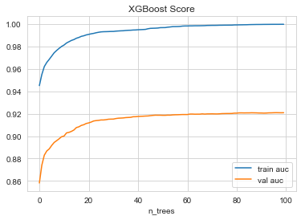

```python
fig, ax = plt.subplots()
ax.plot(model.evals_result()["validation_0"]["auc"], label = "train auc")
ax.plot(model.evals_result()["validation_1"]["auc"], label = "val auc")
ax.legend()
ax.set_xlabel("n_trees")
ax.set_title("XGBoost Score")
plt.show()
```

**Feature Importance**

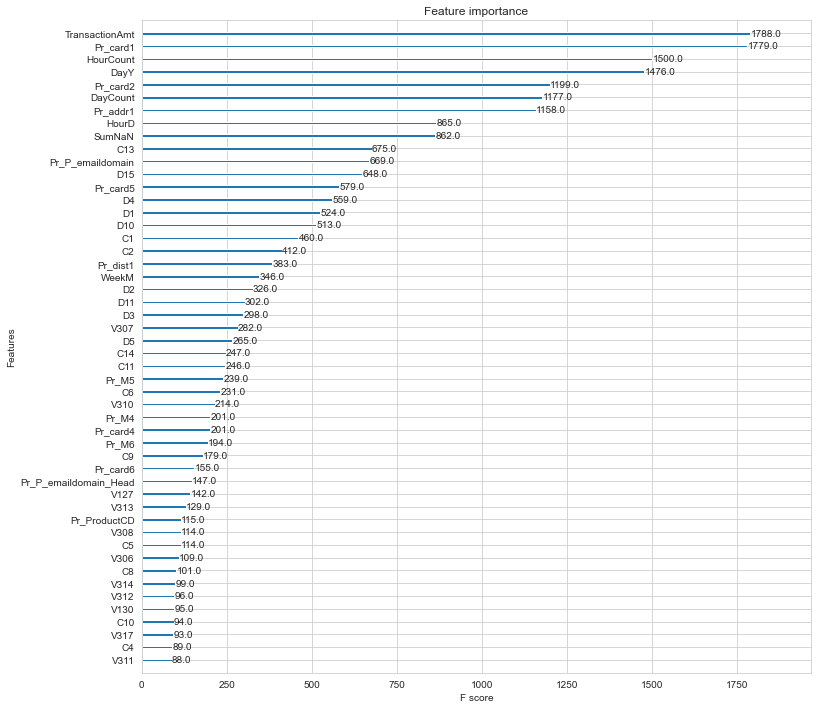

```python
fig, ax = plt.subplots(figsize = (12, 12))
xgb.plot_importance(model, ax = ax, max_num_features = 50)
```

### 5.2.2 Submission

This model got **0.8866 in kaggle private score**.

```python
X_train, X_val, y_train, y_val = split_train_val(train_tr[select_X], Y_array, train_pct = 1)
```

```python
model_xgb = xgb.XGBClassifier(n_estimators = 100, max_depth = 12, eta = 0.15, objective = 'binary:logistic', eval_metric = 'auc', nthread = 2)
```

```python
model_xgb.fit(X_train, y_train)
```

```
XGBClassifier(base_score=None, booster=None, callbacks=None,
              colsample_bylevel=None, colsample_bynode=None,
              colsample_bytree=None, early_stopping_rounds=None,
              enable_categorical=False, eta=0.15, eval_metric='auc',
              feature_types=None, gamma=None, gpu_id=None, grow_policy=None,
              importance_type=None, interaction_constraints=None,
              learning_rate=None, max_bin=None, max_cat_threshold=None,
              max_cat_to_onehot=None, max_delta_step=None, max_depth=12,
              max_leaves=None, min_child_weight=None, missing=nan,
              monotone_constraints=None, n_estimators=100, n_jobs=None,
              nthread=2, num_parallel_tree=None, ...)
```

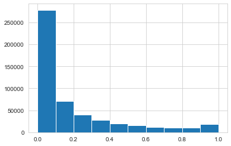

```python
#prediction for test data
ypred = model_xgb.predict_proba(test_tr[select_X])[:,1]
plt.hist(ypred)
plt.show()
```

```python
sample_df2 = pd.read_csv("data/sample_submission.csv")
sample_df2["isFraud"] = ypred
```

```python
sample_df2.to_csv("output/XGB_depth12_2.csv", index = False)
```

# 6. Conclusion and Discussion

**Scores: RandomForest achieved the objective (auc 0.9)**

What improved val auc of RF is **reduction of features** and **max depth tuning**. It is possible that reduction of features prevents useless trees in RF.

[output not shown]

**Why XG Boost score dropped in test data?**

**How to improve auc?**

First, it is necessary to find meaning of new values in categorical columns. There are some new values in test data which did not apper in train data. For example, `card1` of test data has more than 3000 values which are not in train data. Since, `card1` is ranked in the top 5 of feature importance, new values must be the cause of worse auc in test data.

Second, the prediction must be corrected according to the difference of data distribution. RandomForest and XGB assumed that train and test distributions are the same. Parhaps some features must contain regression methods.

Third, more effective features must be created. It is possible if I could find clear patterns of fraudulent transactions. Hence, deeper analysis in EDA is important.

**Other takeaways**

According to feature importance of RF and XGB, I got following insights:

- **Time Series Features works well in tree-based method**: RF and XGB do not work like ARIMA model, but feature engineering compensated this short coming. e.g. `DayY` (day of the year) ranked high in importance.
- **NaN has meaning**: `SumNaN` ranked in the top 10.
- **Probability encoding is efficient but has risk in validation**: some categorical variable has too many unique values such as `card1`. Encoding value into probability reduces number of split of tree in such cases. As shown in following examples, there are specific cards which often used for fraudulent transactions.

```python
print("There are", train_tr["card1"].unique().shape[0], " unique values in card1")
```

```
There are 13553  unique values in card1
```

```python
#dirty card1
train_tr[[Y, "card1"]].groupby("card1").agg(["count", "mean"])[Y].sort_values("mean", ascending = False).query("count > 50").head(5).rename({"mean":"P(Fraud)"}, axis = 1)
```

| card1 | count | P(Fraud) |
| --- | --- | --- |
| 10175 | 72 | 0.625000 |
| 16927 | 98 | 0.561224 |
| 10054 | 79 | 0.556962 |
| 3643 | 121 | 0.520661 |
| 17999 | 101 | 0.485149 |

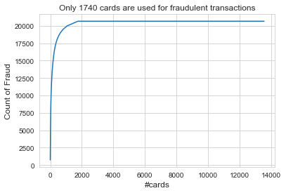

```python
fig, ax = plt.subplots()
sum_array =train_tr[[Y, "card1"]].groupby("card1").sum().sort_values("isFraud", ascending = False)[Y]
plt.plot(np.cumsum(sum_array).to_numpy())
ax.set_xlabel("#cards", fontsize = 12)
ax.set_ylabel("Count of Fraud", fontsize =12)
ax.set_title("Only 1740 cards are used for fraudulent transactions")
plt.show()
```